# GitHub Review

Further details on GitHub and Anaconda

Danilo Freire

danilo.freire@emory.edu

Department of Quantitative Theory and Methods  
Emory University

04 September, 2024

# Lecture Overview

## Learning Objectives

### By the end of this lecture, you will be able to:

1. Understand the difference between cloning and forking a repository
2. Learn how to remove cloned repos
3. Understand the GitHub workflow: change, commit, push, fetch, pull
4. Learn how to keep a forked repository updated
5. Understand what a virtual environment in Anaconda is and how to create one if needed

## Software Installation

### What we will use in this course

- First, please remember to create a GitHub account if you do not have one yet: https://education.github.com/pack. Use your Emory email address to get the GitHub Student Developer Pack for free. Then install the following software:
- [Anaconda](https://www.anaconda.com/products/individual) (Python distribution)
- [GitHub Desktop](https://desktop.github.com/) (Git user interface)
- [Visual Studio Code](https://code.visualstudio.com/) (Code editor)
- Please check the tutorials on the course repository: https://github.com/danilofreire/qtm151/tutorials. They will help you with the installation and setup of the software.
- You can also get help from [Student Tech Support](https://ats.emory.edu/sdl/StudentTechnologySupport/index.html)
- If you have any questions, please let us know!

# GitHub Review

## How to access and edit a remote repository

- Access: download a remote GitHub repository to your local computer to work on it
- Edit: make local changes to the repository and update them to the cloud

There are two ways to access a repository:

- Cloning
- Forking - We will use forking in this course

## Cloning

- Makes a local copy of a repository
- Think of it as downloading a repository onto your local computer
- Unlike forks, clones reference the original repository: you cannot push changes to it unless you have permissions from the owner
- If you do have permissions, you can overwrite the content of the remote repository

[figure not shown]

## Cloning example

- Example repo: https://github.com/danilofreire/qtm151-example-repository
- We can clone the repo using GitHub desktop
  - It does not create a remote copy of the repo in my GitHub page
- If the users cloning the repo have write access they can replace files and folders in the remote GitHub repo
- The purpose of cloning is often to contribute directly to the original repo or work offline

[figure not shown]

## Cloning example

[figure not shown]

## Cloning example

[figure not shown]

## Cloning example: GitHub Desktop

[figure not shown]

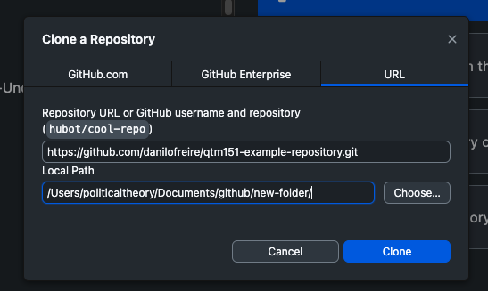

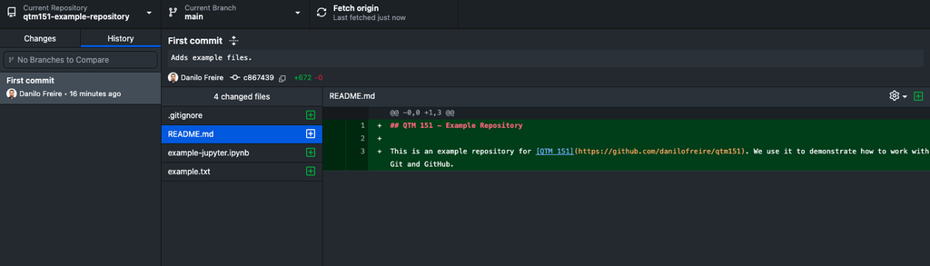

# Questions about cloning?

## Forking

- Creates your own copy of a repository in your remote GitHub page
- Your own copy means that you will be able to contribute changes to your copy of the repository without affecting the original repository!
- Often used to create a personal version of a project for custom modifications
  - You can then submit a pull request to the original repository to suggest changes

## Forking

[figure not shown]

## Forking example

- Example repo: https://github.com/danilofreire/qtm151-example-repository
- We can fork the repo using the GitHub page
  - It creates a remote copy of the repo on your GitHub
  - You can then clone the repo to your local computer and work on it
  - You can push changes to your remote repo
  - See the [GitHub Tutorial](https://github.com/danilofreire/qtm151/blob/main/tutorials/03-github-tutorial.pdf) for more details

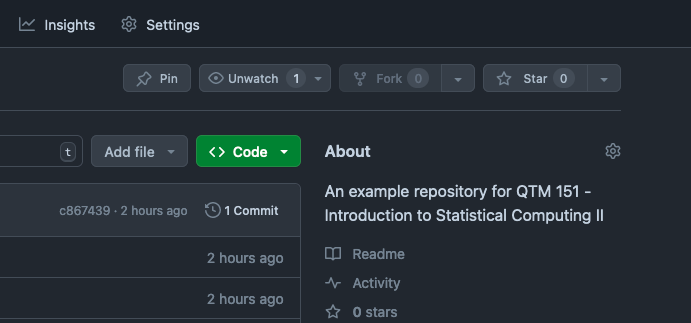

## In our course

[figure not shown]

## In our course

[figure not shown]

## In our course

[figure not shown]

## Comparing cloning and forking

| Feature | Cloning | Forking |
| --- | --- | --- |
| **Local Copy** | Yes | No (initially only on GitHub) |
| **Direct Collaboration** | Yes (if permissions allow) | No (requires pull requests) |
| **Synchronisation** | Yes (with the original repository) | Yes (can fetch updates from the original) |
| **Control** | Limited (depends on permissions) | Full (over the forked copy) |
| **Use Case** | Contributing directly, local development | Independent development, contributing via PRs |
| **Includes** | All files, branches, commit history | All files, commit history, but no issues or PRs |

## Removing cloned and forked repositories

- If you cloned or forked a repository and no longer need it, you can delete the local copy
- Deleting the local copy does not affect the remote repository
- You can also delete the remote repository if you have write access to it (be careful!)

# Questions about forking?

# Great! Now let us see what Jupyter Notebooks are!

[GitHub Review](https://danilofreire.github.io/qtm151/lectures/lecture-02/02-github-review.html)